# Speed-acc-adult EWMA analysis

Kyle MacDonald

10/20/2016

This script analyzes first shift accuracy and RT using an EWMA guesssing model. In the task, we vary the information value and the saliency of the center fixation and measure the effects on accuracy and RT.

## Setup

Load libraries and read in tidy data.

## Setup

Load libraries and read in tidy data.

This script analyzes first shift accuracy and RT using an EWMA guesssing model. In the task, we vary the information value and the saliency of the center fixation and measure the effects on accuracy and RT.

Read data.

## First shift anlayses (RT, Accuracy, EWMA, and DDM)

### RT analysis

First, we analyze RT and accuracy of first shifts that are computed from noun onset.

[output not shown]

Distribution of RTs for correct vs. incorrect shifts from noun onset and from sentence onset

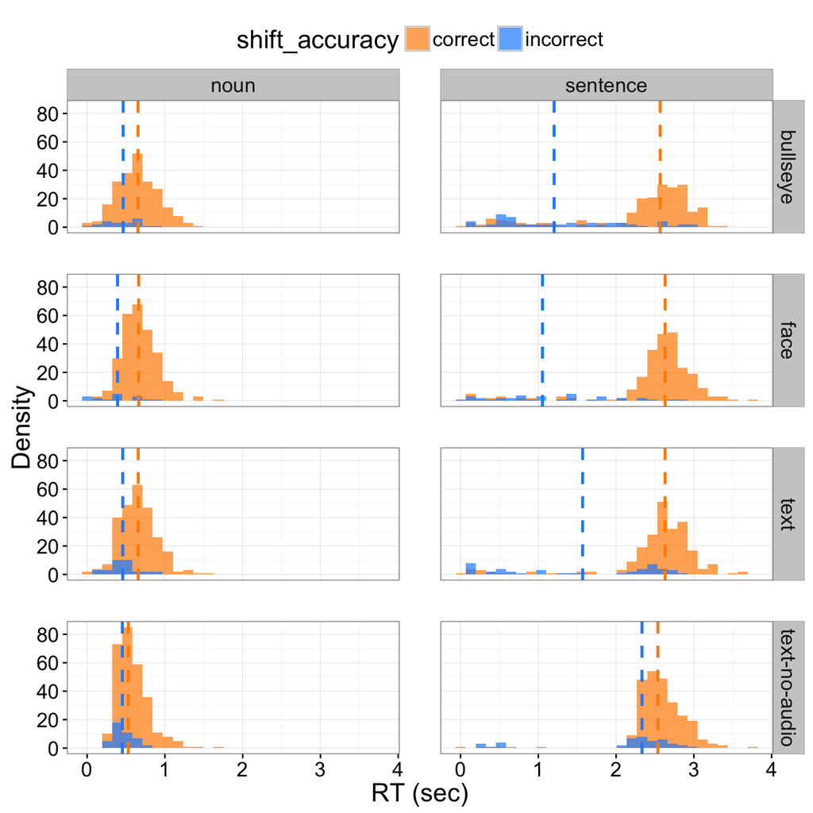

Distribution of RTs for correct vs. incorrect shifts from noun onset and from sentence onset

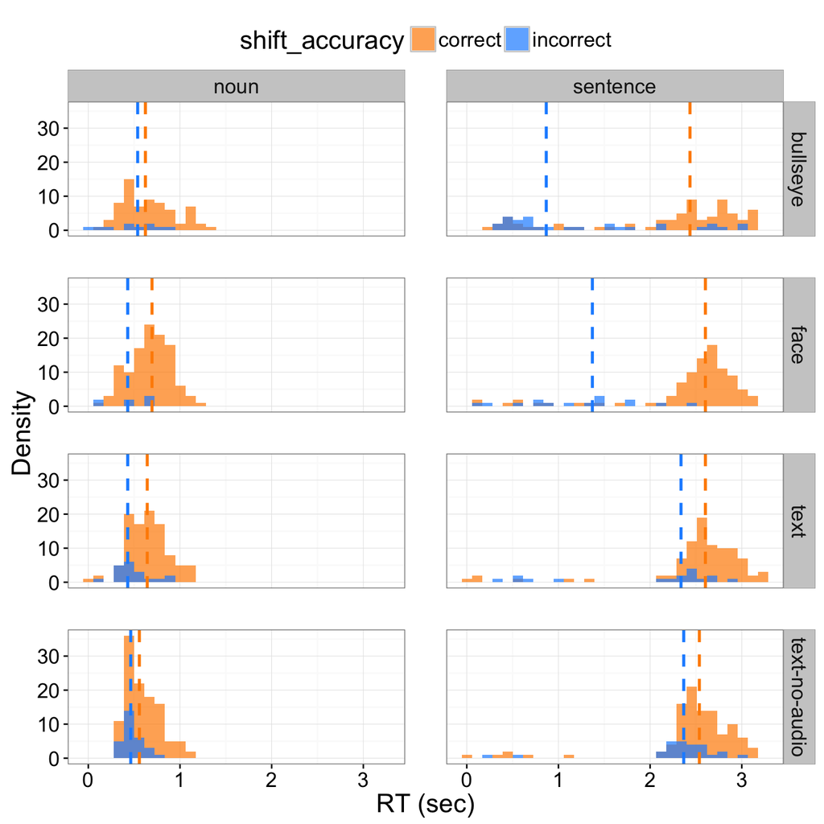

What should we do with shifts that happen before noun onset? My thought is to feed them into the EWMA, but not into the summary analyses and the DDM fits.

#### Plot RT by condition

First we aggregate median RT for each participant.

Then we make a boxplot.

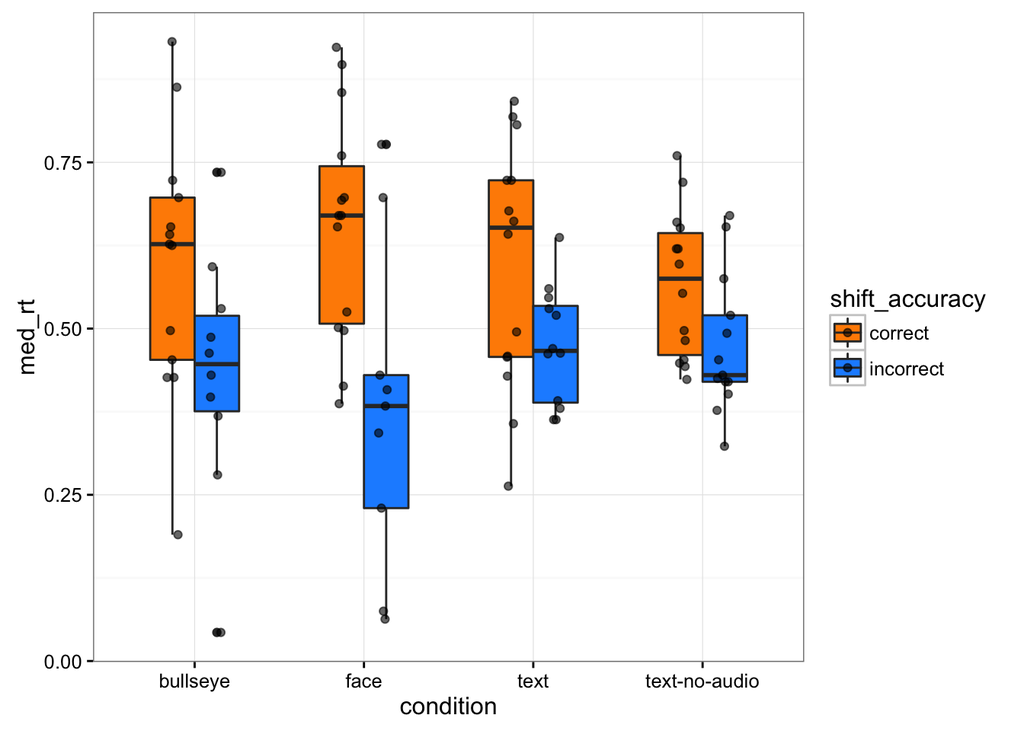

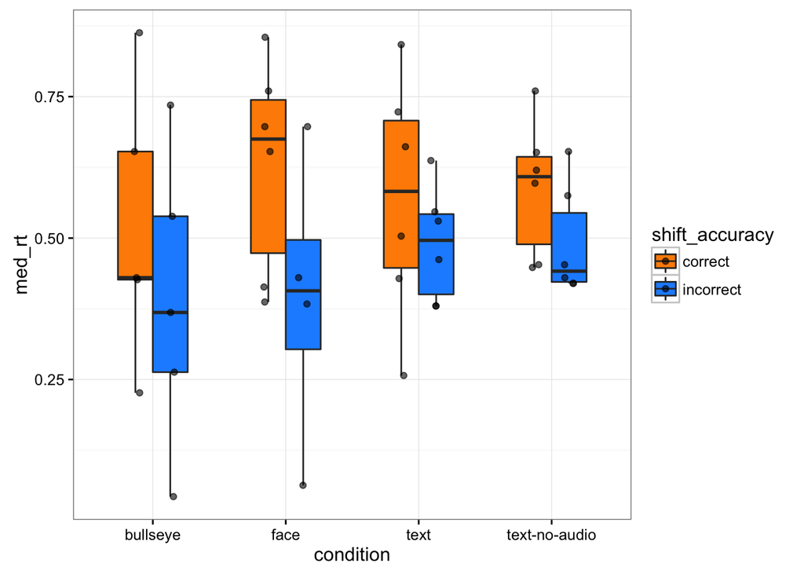

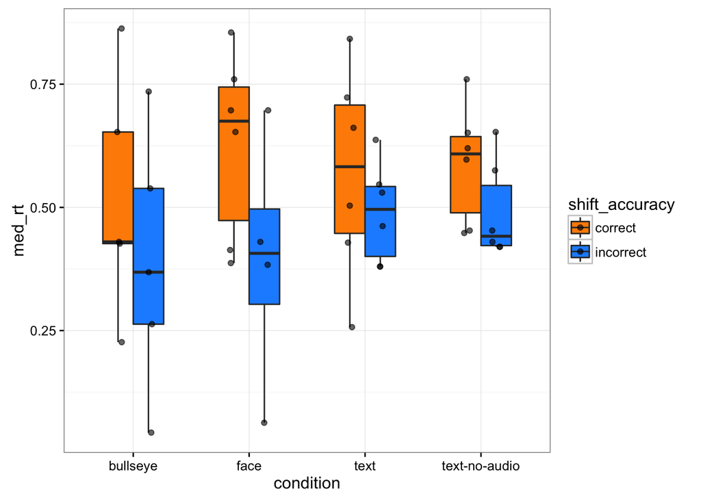

## EWMA filter to model guessing behavior

First we munge the data to feed into the EWMA function.

Fit the EWMA model and plot results.

TODO: Simulate this model across different values of *L* and $\lambda$. *L* controls the width of the threshold. $\lambda$ controls the number of previous trials that go into the moving average computation.

Write EWMA results to .csv so we can use this information in the Drift Diffusion analysis.

Now make a pretty EWMA plot (“control chart”).

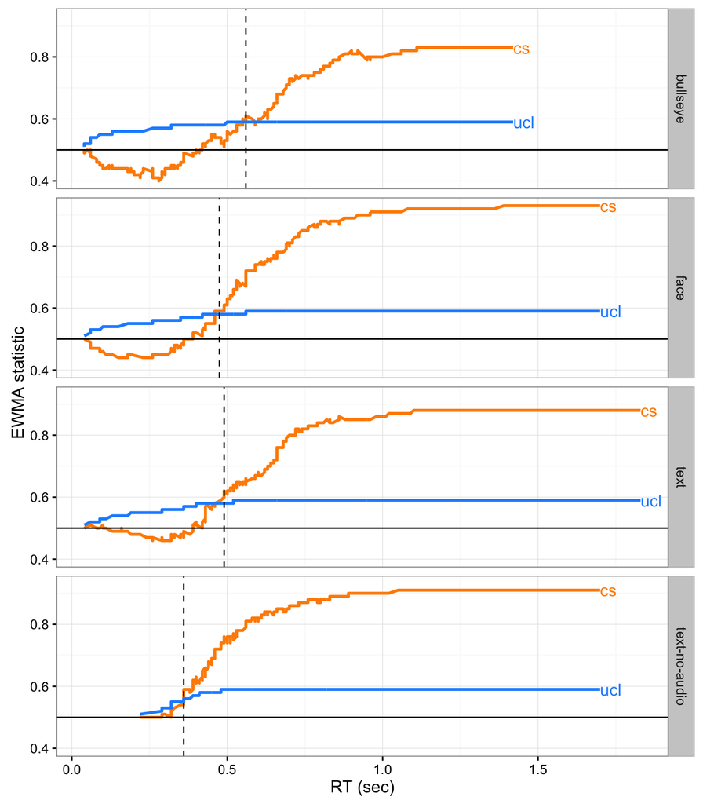

What we can do is compute the proportion of shifts that were categorized as a “fast guess” compared to a “valid response” for each participant for each condition.

Boxplot of proportion guessing by condition.

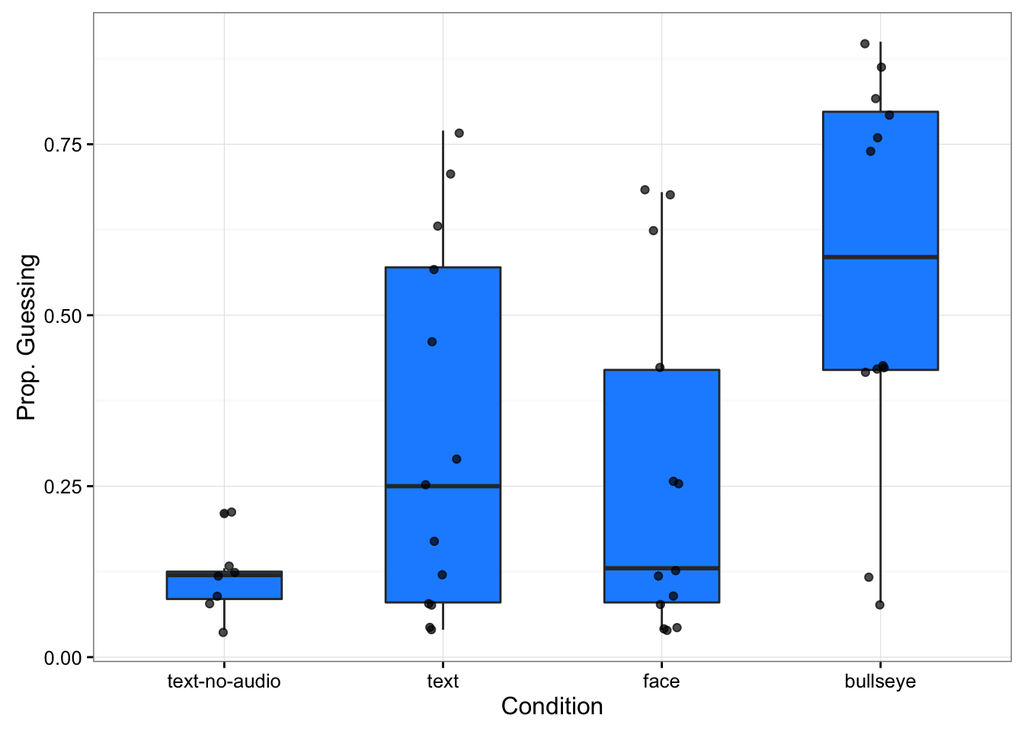

This looks like what we saw in the EWMA control charts: bullseye is mostly guesses, whereas face, text, and text-no-audio are mostly valid responses. However, this analysis still does not caputre one effect in the EWMA chart, which is the amount of *time* each participant spends in a guessing phase vs. a valid response phase for each condition.

To get at this effect, we use a function to compute the difference in time from first guessing response to first valid response for each participant for each condition.

Boxplot of time guessing across the different conditions.

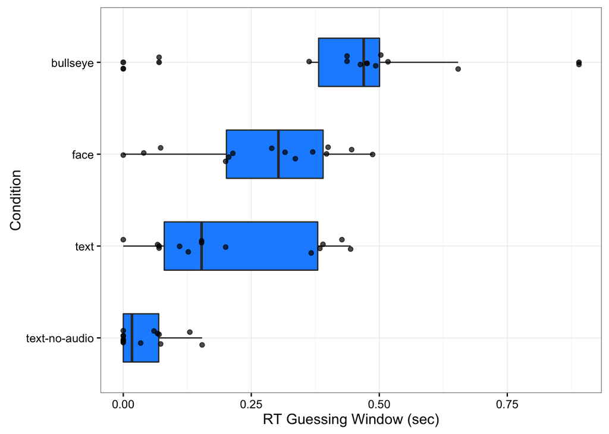

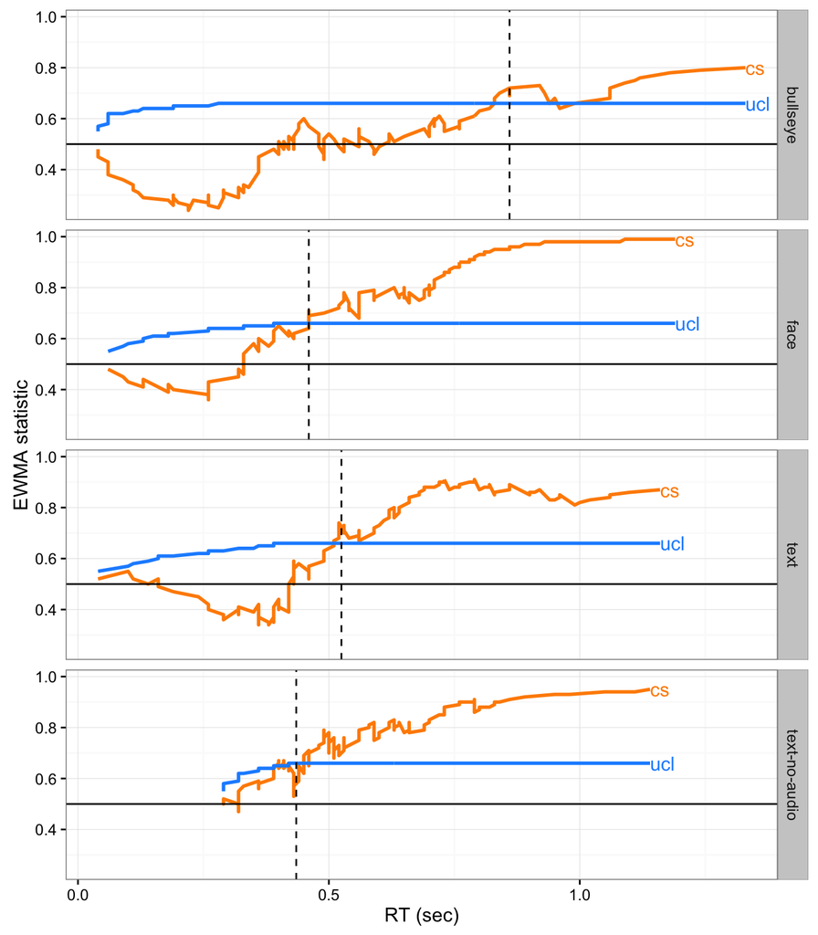

What we can do is compute the proportion of shifts that were categorized as a “fast guess” compared to a “valid response” for each participant for each condition.

Boxplot of proportion guessing by condition.

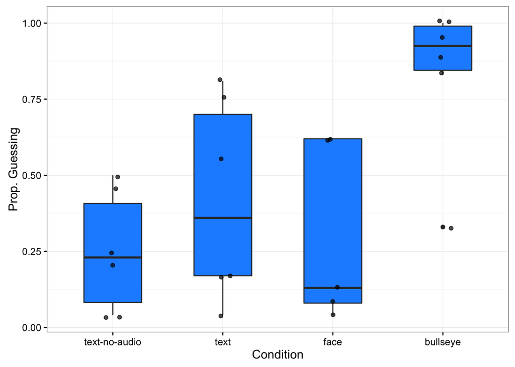

This looks like what we saw in the EWMA control charts: bullseye is mostly guesses, whereas face, text, and text-no-audio are mostly valid responses. However, this analysis still does not caputre one effect in the EWMA chart, which is the amount of *time* each participant spends in a guessing phase vs. a valid response phase for each condition.

To get at this effect, we use a function to compute the difference in time from first guessing response to first valid response for each participant for each condition.

Boxplot of time guessing across the different conditions.

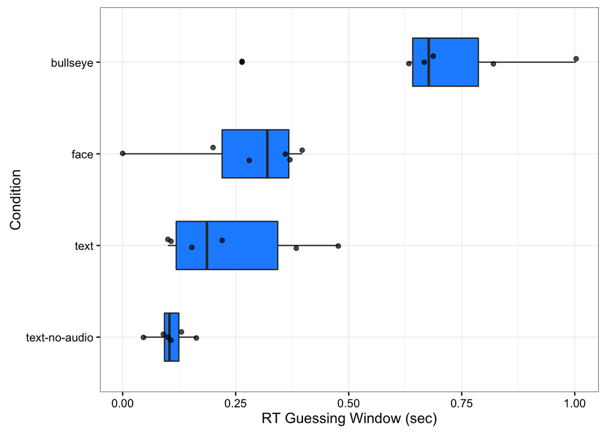

## Stats for EWMA parameters

Model the effect of condition on the the trial-level guessing vs. non-guessing responses. Note that the outcome measure – guessing behavior – is determined by the EWMA control process model described above.

In this model, we include a fixed effect of condition and a random effect of participant. We also test the following contrasts of interest:

- Bullseye vs. Face/Text/Text-no-audio
- Text vs. No-text
- Text-audio vs. Text-no-audio

- Bullseye vs. Face

#### ANOVA for time spent guessing

[output not shown]

[output cut: 22 more lines]

[output not shown]